# Supply Data Analysis

### by Rewan Emam

> **report questions:**
> 1. What is the supply to demand dynamic and whether they match?
> 2. Where are the hours of oversupply? Can we shift some of them to undersupply hours?

```python
# the imports statements
import numpy as np
import pandas as pd
import matplotlib.pyplot as plt
import matplotlib.cm as cm
from matplotlib.colors import Normalize

%matplotlib inline
```

```python
# loading the data

driver_activity = pd.read_csv('https://raw.githubusercontent.com/RewanEmam/Supply-Data-Analysis/main/Hourly_DriverActivity_1.csv%20-%20Hourly_DriverActivity_1.csv', sep = ',', index_col=0)
overview_search = pd.read_csv('https://raw.githubusercontent.com/RewanEmam/Supply-Data-Analysis/main/Hourly_OverviewSearch_1.csv%20-%20Hourly_OverviewSearch_1.csv', sep = ',', index_col=0)
```

### Data Exploration

```python
# viewing the driver activity data
driver_activity
```

| Date | Active drivers | Online (h) | Has booking (h) | Waiting for booking (h) | Busy (h) | Hours per active driver | Rides per online hour | Finished Rides |
| --- | --- | --- | --- | --- | --- | --- | --- | --- |
| 2016-12-18 23 | 52 | 18 | 6 | 11 | 11 | 0.3 | 0.67 | 12.0 |
| 2016-12-18 22 | 59 | 20 | 11 | 9 | 12 | 0.3 | 1.40 | 28.0 |
| 2016-12-18 21 | 72 | 25 | 7 | 18 | 15 | 0.3 | 0.64 | 16.0 |
| 2016-12-18 20 | 86 | 29 | 7 | 23 | 15 | 0.3 | 0.52 | 15.0 |
| 2016-12-18 19 | 82 | 31 | 14 | 17 | 19 | 0.4 | 1.16 | 36.0 |
| ... | ... | ... | ... | ... | ... | ... | ... | ... |
| 2016-11-14 04 | 15 | 6 | 0 | 6 | 6 | 0.4 | 0.00 | NaN |
| 2016-11-14 03 | 18 | 7 | 0 | 7 | 7 | 0.4 | 0.00 | NaN |
| 2016-11-14 02 | 21 | 7 | 0 | 7 | 9 | 0.3 | 0.14 | 1.0 |
| 2016-11-14 01 | 29 | 9 | 1 | 8 | 11 | 0.3 | 0.22 | 2.0 |
| 2016-11-14 00 | 38 | 14 | 3 | 11 | 12 | 0.4 | 0.43 | 6.0 |

840 rows × 8 columns

```python
# viewing the overview search data
overview_search
```

| Date | People saw 0 cars (unique) | People saw +1 cars (unique) | Coverage Ratio (unique) |
| --- | --- | --- | --- |
| 2016-12-18 23 | 9 | 32 | 78 |
| 2016-12-18 22 | 29 | 64 | 69 |
| 2016-12-18 21 | 5 | 39 | 89 |
| 2016-12-18 20 | 13 | 48 | 79 |
| 2016-12-18 19 | 12 | 77 | 87 |
| ... | ... | ... | ... |
| 2016-11-14 04 | 4 | 4 | 50 |
| 2016-11-14 03 | 1 | 2 | 67 |
| 2016-11-14 02 | 3 | 6 | 67 |
| 2016-11-14 01 | 8 | 8 | 50 |
| 2016-11-14 00 | 9 | 15 | 63 |

839 rows × 3 columns

```python
driver_activity.describe()
```

|  | Active drivers | Online (h) | Has booking (h) | Waiting for booking (h) | Busy (h) | Hours per active driver | Rides per online hour | Finished Rides |
| --- | --- | --- | --- | --- | --- | --- | --- | --- |
| count | 840.000000 | 840.000000 | 840.000000 | 840.000000 | 840.000000 | 840.000000 | 840.000000 | 795.000000 |
| mean | 61.603571 | 23.197619 | 6.308333 | 16.903571 | 15.269048 | 0.370000 | 0.568786 | 14.764780 |
| std | 25.945275 | 11.101503 | 5.536652 | 9.068747 | 6.414301 | 0.068214 | 0.386042 | 11.362529 |
| min | 9.000000 | 2.000000 | 0.000000 | 2.000000 | 1.000000 | 0.100000 | 0.000000 | 1.000000 |
| 25% | 41.000000 | 14.000000 | 2.000000 | 10.000000 | 10.000000 | 0.300000 | 0.290000 | 6.000000 |
| 50% | 63.000000 | 23.000000 | 5.000000 | 16.000000 | 15.000000 | 0.400000 | 0.500000 | 12.000000 |
| 75% | 80.250000 | 31.000000 | 9.000000 | 23.000000 | 20.000000 | 0.400000 | 0.790000 | 20.000000 |
| max | 129.000000 | 56.000000 | 29.000000 | 48.000000 | 37.000000 | 0.600000 | 2.030000 | 62.000000 |

```python
overview_search.describe()
```

|  | People saw 0 cars (unique) | People saw +1 cars (unique) | Coverage Ratio (unique) |
| --- | --- | --- | --- |
| count | 839.000000 | 839.000000 | 839.000000 |
| mean | 12.240763 | 36.041716 | 75.661502 |
| std | 16.602303 | 25.160951 | 18.342403 |
| min | 0.000000 | 0.000000 | 0.000000 |
| 25% | 3.000000 | 19.000000 | 66.000000 |
| 50% | 6.000000 | 32.000000 | 80.000000 |
| 75% | 14.000000 | 49.000000 | 89.000000 |
| max | 129.000000 | 172.000000 | 100.000000 |

```python
# checking for nan values that needs to be cleaned
print(f"does the driver dataset have nan values: {driver_activity.isnull().values.any()} and overview dataset: {overview_search.isnull().values.any()}")
```

```
does the driver dataset have nan values: True and overview dataset: False
```

### Data Cleaning

**In this section I will clean the data from both datasets.**

first I will replace the nan values with zeros because the driver activity dataset has nan values

```python
driver_activity = driver_activity.fillna(0)
```

```python
# checking to see if there are still nan values in the dataset
print(f"does the driver dataset have nan values: {driver_activity.isnull().values.any()} and overview dataset: {overview_search.isnull().values.any()}")
```

```
does the driver dataset have nan values: False and overview dataset: False
```

perfect there are no nan values present

```python
overview_search = overview_search.fillna(0)
```

```python
driver_activity.rename(columns = {'Date' : 'date' , 'Active drivers': 'active_drivers' , 'Online (h)':'online', 'Has booking (h)':'booked' , 'Waiting for booking (h)':'waiting', 'Busy (h)': 'busy', 'Hours per active driver' : 'hpd' , 'Rides per online hour' : 'rph', 'Finished Rides': 'finished' }, inplace = True)
```

```python
overview_search.rename(columns = {'People saw 0 cars (unique)' : 'zero_cars' , 'People saw +1 cars (unique)' : 'saw_cars' , 'Coverage Ratio (unique)' : 'cr'} ,inplace = True )
overview_search
```

| Date | zero_cars | saw_cars | cr |
| --- | --- | --- | --- |
| 2016-12-18 23 | 9 | 32 | 78 |
| 2016-12-18 22 | 29 | 64 | 69 |
| 2016-12-18 21 | 5 | 39 | 89 |
| 2016-12-18 20 | 13 | 48 | 79 |
| 2016-12-18 19 | 12 | 77 | 87 |
| ... | ... | ... | ... |
| 2016-11-14 04 | 4 | 4 | 50 |
| 2016-11-14 03 | 1 | 2 | 67 |
| 2016-11-14 02 | 3 | 6 | 67 |
| 2016-11-14 01 | 8 | 8 | 50 |
| 2016-11-14 00 | 9 | 15 | 63 |

839 rows × 3 columns

### Exploratory Data Analysis

**1- Show which 36 hours in a week are most undersupplied. Show/describe your decision based on sample data?**

to calculate the undersupplied we need to calculate the number of hours where the driver wasn't available to cover the client's needs. the driver is not availabe if they are busy or has booking.

```python
driver_activity['supply'] = (driver_activity['busy'] + driver_activity['booked'])/driver_activity['active_drivers']
driver_activity
```

| Date | active_drivers | online | booked | waiting | busy | hpd | rph | finished | supply |
| --- | --- | --- | --- | --- | --- | --- | --- | --- | --- |
| 2016-12-18 23 | 52 | 18 | 6 | 11 | 11 | 0.3 | 0.67 | 12.0 | 0.326923 |
| 2016-12-18 22 | 59 | 20 | 11 | 9 | 12 | 0.3 | 1.40 | 28.0 | 0.389831 |
| 2016-12-18 21 | 72 | 25 | 7 | 18 | 15 | 0.3 | 0.64 | 16.0 | 0.305556 |
| 2016-12-18 20 | 86 | 29 | 7 | 23 | 15 | 0.3 | 0.52 | 15.0 | 0.255814 |
| 2016-12-18 19 | 82 | 31 | 14 | 17 | 19 | 0.4 | 1.16 | 36.0 | 0.402439 |
| ... | ... | ... | ... | ... | ... | ... | ... | ... | ... |
| 2016-11-14 04 | 15 | 6 | 0 | 6 | 6 | 0.4 | 0.00 | 0.0 | 0.400000 |
| 2016-11-14 03 | 18 | 7 | 0 | 7 | 7 | 0.4 | 0.00 | 0.0 | 0.388889 |
| 2016-11-14 02 | 21 | 7 | 0 | 7 | 9 | 0.3 | 0.14 | 1.0 | 0.428571 |
| 2016-11-14 01 | 29 | 9 | 1 | 8 | 11 | 0.3 | 0.22 | 2.0 | 0.413793 |
| 2016-11-14 00 | 38 | 14 | 3 | 11 | 12 | 0.4 | 0.43 | 6.0 | 0.394737 |

840 rows × 9 columns

```python
overview_search['total'] = overview_search['saw_cars'] / (overview_search['cr']/100)
overview_search = overview_search.fillna(0)
```

```python
driver_activity['availabe_drivers'] = (driver_activity['online'] - driver_activity['supply'])/overview_search['total']
driver_activity['peak'] = (overview_search['zero_cars'] + overview_search['saw_cars'])/100
driver_activity = driver_activity.fillna(0)
```

```python
driver_activity['unsupplied'] = driver_activity['busy'] + driver_activity['booked']
udersupplied_data = driver_activity.sort_values(by='unsupplied', ascending=False).head(36)
udersupplied_data
```

| Date | active_drivers | online | booked | waiting | busy | hpd | rph | finished | supply | availabe_drivers | peak | unsupplied |
| --- | --- | --- | --- | --- | --- | --- | --- | --- | --- | --- | --- | --- |
| 2016-12-08 19 | 103 | 40 | 27 | 14 | 33 | 0.4 | 1.32 | 53.0 | 0.582524 | 0.257871 | 1.53 | 60 |
| 2016-12-08 18 | 104 | 40 | 26 | 14 | 33 | 0.4 | 1.05 | 42.0 | 0.567308 | 0.225330 | 1.74 | 59 |
| 2016-12-08 20 | 116 | 42 | 21 | 21 | 37 | 0.4 | 0.86 | 36.0 | 0.500000 | 0.405778 | 1.02 | 58 |
| 2016-12-09 20 | 109 | 38 | 24 | 14 | 30 | 0.3 | 1.50 | 57.0 | 0.495413 | 0.266785 | 1.40 | 54 |
| 2016-12-16 18 | 92 | 41 | 29 | 11 | 25 | 0.4 | 1.15 | 47.0 | 0.586957 | 0.174565 | 2.31 | 54 |
| 2016-12-08 21 | 108 | 36 | 18 | 18 | 35 | 0.3 | 1.39 | 50.0 | 0.490741 | 0.350420 | 1.01 | 53 |
| 2016-12-07 19 | 101 | 35 | 21 | 14 | 32 | 0.3 | 0.89 | 31.0 | 0.524752 | 0.282070 | 1.22 | 53 |
| 2016-12-16 21 | 126 | 50 | 22 | 28 | 30 | 0.4 | 0.80 | 40.0 | 0.412698 | 0.259280 | 1.92 | 52 |
| 2016-11-24 18 | 106 | 43 | 23 | 21 | 28 | 0.4 | 0.86 | 37.0 | 0.481132 | 0.468246 | 0.91 | 51 |
| 2016-12-17 00 | 95 | 34 | 22 | 12 | 28 | 0.4 | 1.38 | 47.0 | 0.526316 | 0.200842 | 1.66 | 50 |
| 2016-12-08 17 | 104 | 32 | 17 | 16 | 33 | 0.3 | 0.91 | 29.0 | 0.480769 | 0.288556 | 1.10 | 50 |
| 2016-12-16 20 | 108 | 38 | 25 | 13 | 24 | 0.4 | 1.63 | 62.0 | 0.453704 | 0.144073 | 2.59 | 49 |
| 2016-12-09 21 | 96 | 35 | 22 | 13 | 26 | 0.4 | 1.60 | 56.0 | 0.500000 | 0.206324 | 1.66 | 48 |
| 2016-12-05 19 | 93 | 39 | 24 | 15 | 23 | 0.4 | 0.92 | 36.0 | 0.505376 | 0.339658 | 1.13 | 47 |
| 2016-12-05 18 | 86 | 34 | 23 | 12 | 24 | 0.4 | 1.18 | 40.0 | 0.546512 | 0.275716 | 1.22 | 47 |
| 2016-12-07 18 | 88 | 24 | 13 | 11 | 34 | 0.3 | 1.08 | 26.0 | 0.534091 | 0.191693 | 1.23 | 47 |
| 2016-12-16 19 | 93 | 33 | 24 | 8 | 22 | 0.4 | 1.09 | 36.0 | 0.494624 | 0.119878 | 2.70 | 46 |
| 2016-12-16 23 | 119 | 43 | 17 | 26 | 29 | 0.4 | 1.14 | 49.0 | 0.386555 | 0.382326 | 1.12 | 46 |
| 2016-12-13 19 | 98 | 36 | 21 | 16 | 25 | 0.4 | 1.17 | 42.0 | 0.469388 | 0.312498 | 1.13 | 46 |
| 2016-12-06 19 | 108 | 43 | 22 | 21 | 24 | 0.4 | 0.65 | 28.0 | 0.425926 | 0.477520 | 0.89 | 46 |
| 2016-11-23 18 | 102 | 40 | 23 | 17 | 22 | 0.4 | 1.07 | 43.0 | 0.441176 | 0.283050 | 1.40 | 45 |
| 2016-12-16 22 | 129 | 47 | 17 | 30 | 27 | 0.4 | 0.98 | 46.0 | 0.341085 | 0.366294 | 1.28 | 44 |
| 2016-11-24 19 | 116 | 45 | 16 | 28 | 28 | 0.4 | 0.71 | 32.0 | 0.379310 | 0.503413 | 0.89 | 44 |
| 2016-12-06 18 | 90 | 31 | 19 | 12 | 25 | 0.3 | 1.19 | 37.0 | 0.488889 | 0.264729 | 1.15 | 44 |
| 2016-11-29 19 | 110 | 43 | 22 | 21 | 21 | 0.4 | 0.79 | 34.0 | 0.390909 | 0.368640 | 1.16 | 43 |
| 2016-12-17 01 | 83 | 29 | 20 | 9 | 23 | 0.3 | 2.03 | 59.0 | 0.518072 | 0.172078 | 1.65 | 43 |
| 2016-12-07 17 | 106 | 35 | 12 | 23 | 31 | 0.3 | 0.49 | 17.0 | 0.405660 | 0.655851 | 0.53 | 43 |
| 2016-11-17 18 | 83 | 31 | 18 | 13 | 25 | 0.4 | 1.00 | 31.0 | 0.518072 | 0.239267 | 1.27 | 43 |
| 2016-12-12 18 | 78 | 30 | 15 | 15 | 27 | 0.4 | 0.63 | 19.0 | 0.538462 | 0.481583 | 0.61 | 42 |
| 2016-12-09 22 | 104 | 45 | 21 | 24 | 21 | 0.4 | 0.78 | 35.0 | 0.403846 | 0.379067 | 1.17 | 42 |
| 2016-12-15 19 | 70 | 30 | 26 | 4 | 16 | 0.4 | 1.47 | 44.0 | 0.600000 | 0.159704 | 1.86 | 42 |
| 2016-12-09 19 | 96 | 37 | 20 | 18 | 22 | 0.4 | 1.05 | 39.0 | 0.437500 | 0.275943 | 1.33 | 42 |
| 2016-11-29 18 | 100 | 34 | 20 | 15 | 22 | 0.3 | 0.88 | 30.0 | 0.420000 | 0.279106 | 1.21 | 42 |
| 2016-11-25 18 | 91 | 42 | 23 | 19 | 19 | 0.5 | 0.81 | 34.0 | 0.461538 | 0.386404 | 1.08 | 42 |
| 2016-12-17 21 | 103 | 39 | 18 | 21 | 24 | 0.4 | 1.21 | 47.0 | 0.407767 | 0.317582 | 1.21 | 42 |
| 2016-11-23 19 | 115 | 49 | 18 | 32 | 23 | 0.4 | 0.61 | 30.0 | 0.356522 | 0.630310 | 0.77 | 41 |

```python
plt.figure(figsize=(20,7))
my_cmap = cm.get_cmap('Spectral')
my_norm = Normalize(vmin=0, vmax=65)
plt.bar(udersupplied_data['date'] , udersupplied_data['unsupplied'], color=my_cmap(my_norm(udersupplied_data['unsupplied'])));
plt.xticks(udersupplied_data['date'], udersupplied_data['date'], rotation = 85, fontsize=20);
plt.title("most undersupplied 36 hours");
plt.xlabel("hours of day");
plt.ylabel("undersuppliment");
```

[output not shown]

**24-hour curve of average supply and demand (to illustrate match/mismatch).**

online - busy - has booking / active drives - > supply

```python
int(str(driver_activity['date'][23:24])[-28:-26])
```

[output not shown]

```python
int(driver_activity['date'][100][-2:])
```

[output not shown]

```python
driver_activity['date'][0]
```

```
'2016-12-18 23'
```

```python
driver_activity['supply'][0]
```

```
0.3269230769230769
```

```python
dict = {1 : 0 , 'second' : 2}
dict[1] += 5
dict[1]
```

```
5
```

```python
driver_activity[0:1]
```

|  | date | active_drivers | online | booked | waiting | busy | hpd | rph | finished | supply | availabe_drivers | peak | unsupplied |
| --- | --- | --- | --- | --- | --- | --- | --- | --- | --- | --- | --- | --- | --- |
| 0 | 2016-12-18 23 | 52 | 18 | 6 | 11 | 11 | 0.3 | 0.67 | 12.0 | 0.326923 | 0.430781 | 0.41 | 17 |

```python
l = []
dictt = {0:0}
for i in range(0,len(driver_activity),24):
#     print(driver_activity[i-1:i])
    l.append(driver_activity['supply'][i])
len(l) , np.sum(l)
dictt[0] += np.average(l)
dictt
```

```
{0: 0.35983992744709054}
```

```python
dict_ = {0: 0, 1: 0, 2: 0, 3: 0, 4: 0, 5:0, 6: 0, 7: 0, 8: 0, 9: 0, 10: 0, 11: 0, 12: 0, 13: 0, 14: 0, 15: 0, 16: 0, 17: 0, 18: 0, 19:0 , 20:0 , 21:0 , 22:0 , 23:0}
for x in range(23,-1,-1):
    list_ = []
    for i in range(x, len(driver_activity),24):
        list_.append(driver_activity['supply'][i])
    dict_[x] += np.average(list_)
dict_
```

```
{0: 0.35983992744709054,
 1: 0.3353053027840607,
 2: 0.32881734186328954,
 3: 0.3395036941141348,
 4: 0.3959843103193516,
 5: 0.43030085306959326,
 6: 0.3511397576737896,
 7: 0.31985573049469856,
 8: 0.3147444202426017,
 9: 0.3230459563816655,
 10: 0.3269618539296409,
 11: 0.3236993141357791,
 12: 0.31121279440657673,
 13: 0.3250755893201993,
 14: 0.3995911497293875,
 15: 0.4017495179420424,
 16: 0.31995168823086984,
 17: 0.30312331400568576,
 18: 0.3410448077668945,
 19: 0.39437756592810846,
 20: 0.38795942844485226,
 21: 0.35372304314649233,
 22: 0.3376339582886058,
 23: 0.3781515541134667}
```

```python
overview_search['avg_demand'] =  (overview_search['zero_cars'] + overview_search['saw_cars'])/overview_search['total']
```

```python
overview_search['avg_demand'].fillna(1)
```

```
0      0.999375
1      1.002656
2      1.004103
3      1.003958
4      1.005584
         ...
834    1.000000
835    1.005000
836    1.005000
837    1.000000
838    1.008000
Name: avg_demand, Length: 839, dtype: float64
```

```python
overview_search['avg_demand'][18]
```

```
0.9954545454545455
```

```python
dict2_ = {0: 0, 1: 0, 2: 0, 3: 0, 4: 0, 5:0, 6: 0, 7: 0, 8: 0, 9: 0, 10: 0, 11: 0, 12: 0, 13: 0, 14: 0, 15: 0, 16: 0, 17: 0, 18: 0, 19:0 , 20:0 , 21:0 , 22:0 , 23:0}
for x in range(23,-1,-1):
    list2_ = []
    for i in range(x, len(overview_search),24):
        list2_.append(overview_search['avg_demand'][i])
    dict2_[x] += np.average(list2_)
dict2_[18] = overview_search['avg_demand'][18]
dict2_[19] = overview_search['avg_demand'][19]
dict2_
```

```
{0: 1.000305710983293,
 1: 1.000261736224683,
 2: 1.0003443763173376,
 3: 1.0002332412321755,
 4: 1.0005875332488938,
 5: 0.9997458076907721,
 6: 0.999428528244825,
 7: 0.9996090592496277,
 8: 1.000122889689848,
 9: 1.0003915598946802,
 10: 0.9994590617734537,
 11: 0.9988493800655512,
 12: 0.9995801843459773,
 13: 0.998818218471298,
 14: 1.0000351539982486,
 15: 1.0008082216931997,
 16: 1.0004081414383938,
 17: 1.0010302794777588,
 18: 0.9954545454545455,
 19: 1.0014545454545456,
 20: 1.000347419162393,
 21: 1.000193503149521,
 22: 1.000234749376684,
 23: 1.001041749907458}
```

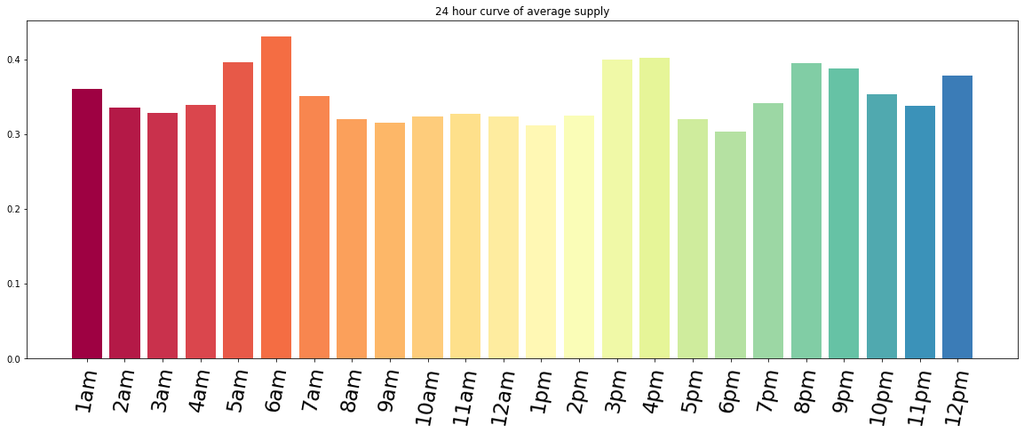

```python
plt.figure(figsize=(20,7))
my_cmap = cm.get_cmap('Spectral')
my_norm = Normalize(vmin=0, vmax=25)
plt.bar(*zip(*dict_.items()),color=my_cmap(my_norm([i for i in range(24)])))
plt.xticks([i for i in range(24)], [str(i)+"am" for i in range(1 ,13)] + [str(i)+"pm" for i in range(1 ,13)] ,rotation = 80, fontsize=23);
plt.title("24 hour curve of average supply");
```

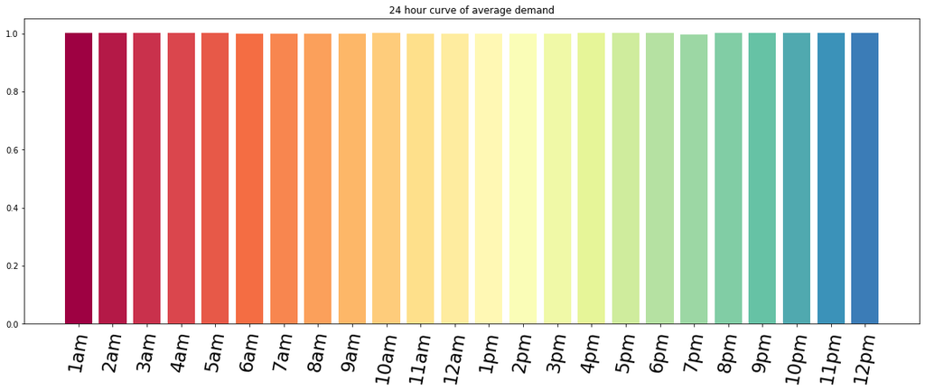

```python
plt.figure(figsize=(20,7))
my_cmap = cm.get_cmap('Spectral')
my_norm = Normalize(vmin=0, vmax=25)
plt.bar(*zip(*dict2_.items()),color=my_cmap(my_norm([i for i in range(24)])))
plt.xticks([i for i in range(24)], [str(i)+"am" for i in range(1 ,13)] + [str(i)+"pm" for i in range(1 ,13)] ,rotation = 80, fontsize=23);
plt.title("24 hour curve of average demand");
```

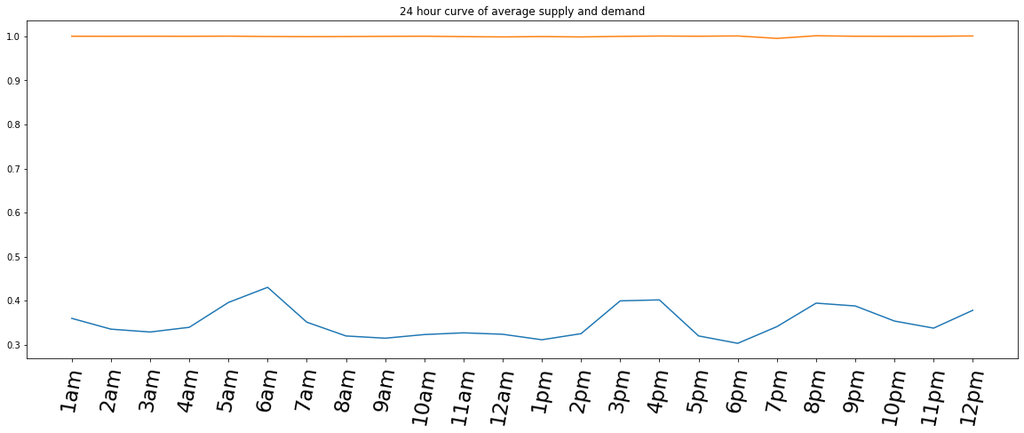

```python
plt.figure(figsize=(20,7))
x, y = zip(*sorted(dict_.items())) # unpack a list of pairs into two tuples
i, j = zip(*sorted(dict2_.items()))
plt.plot(x, y)
plt.plot(i,j)
plt.xticks([i for i in range(24)], [str(i)+"am" for i in range(1 ,13)] + [str(i)+"pm" for i in range(1 ,13)] ,rotation = 80, fontsize=23);
plt.title("24 hour curve of average supply and demand");
```

**Visualisation of hours where we lack supply during a weekly period. This one we can send to drivers to show when to online for extra hours.**

```python
driver_activity = driver_activity.fillna(0)
peak_ordered = driver_activity.sort_values(by='peak', ascending=False).head(50)
peak_ordered['pup'] = peak_ordered['unsupplied']/peak_ordered['peak']
# peak_ordered
```

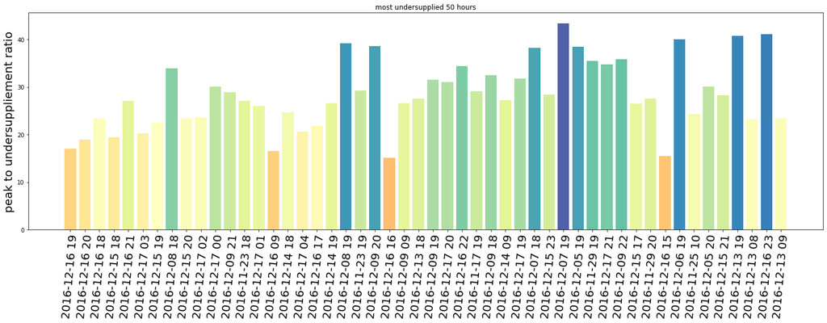

```python
plt.figure(figsize=(25,7))
my_cmap = cm.get_cmap('Spectral')
my_norm = Normalize(vmin=0, vmax=45)
plt.bar(peak_ordered['date'] , peak_ordered['pup'], color=my_cmap(my_norm(peak_ordered['pup'])));
plt.xticks(peak_ordered['date'], peak_ordered['date'], rotation = 85, fontsize=20);
plt.title("most undersupplied 50 hours");
plt.ylabel("peak to undersuppliement ratio", fontsize=20);
```

**Estimate number of hours needed to ensure we have a high Coverage Ratio during most peak hours.**

```python
peak_ordered['supplyPerPeak'] = 1 - ((peak_ordered['online'] - peak_ordered['unsupplied'])/peak_ordered['peak'])
peak_ordered['hourPerPeak'] = peak_ordered['supplyPerPeak']/peak_ordered['peak']
peak_ordered.sort_values(by='hourPerPeak', ascending=False)
supplyPerPeak_data = supplyPerPeak_data.sort_values(by='hourPerPeak', ascending=False)
supplyPerPeak_data
```

[output not shown]

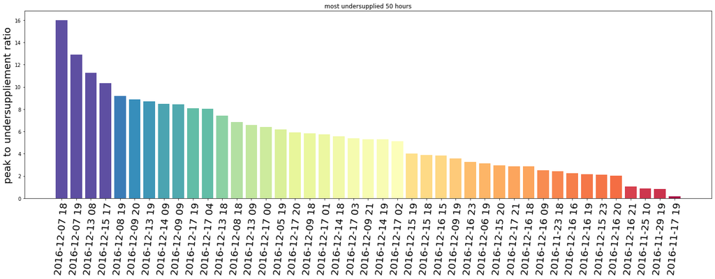

```python
plt.figure(figsize=(25,7))
my_cmap = cm.get_cmap('Spectral')
my_norm = Normalize(vmin=0, vmax=10)
plt.bar(supplyPerPeak_data['date'] , supplyPerPeak_data['hourPerPeak'], color=my_cmap(my_norm(supplyPerPeak_data['hourPerPeak'])));
plt.xticks(supplyPerPeak_data['date'], supplyPerPeak_data['date'], rotation = 85, fontsize=20);
plt.title("most undersupplied 50 hours");
plt.ylabel("peak to undersuppliement ratio", fontsize=20);
```